# Risk Factor Analysis

## Outcome Variable

**Outcome Variable:** wasted

## Predictor Variables

**Intervention Variable:** anywast06

**Adjustment Set:**

unadjusted

## Stratifying Variables

The analysis was stratified on these variable(s):

- agecat
- studyid
- country

## Data Summary

| agecat | studyid | country | anywast06 | wasted | n_cell | n |
| --- | --- | --- | --- | --- | --- | --- |
| Birth | ki0047075b-MAL-ED | BANGLADESH | 0 | 0 | 186 | 241 |
| Birth | ki0047075b-MAL-ED | BANGLADESH | 0 | 1 | 0 | 241 |
| Birth | ki0047075b-MAL-ED | BANGLADESH | 1 | 0 | 15 | 241 |
| Birth | ki0047075b-MAL-ED | BANGLADESH | 1 | 1 | 40 | 241 |
| Birth | ki0047075b-MAL-ED | BRAZIL | 0 | 0 | 170 | 183 |
| Birth | ki0047075b-MAL-ED | BRAZIL | 0 | 1 | 0 | 183 |
| Birth | ki0047075b-MAL-ED | BRAZIL | 1 | 0 | 7 | 183 |
| Birth | ki0047075b-MAL-ED | BRAZIL | 1 | 1 | 6 | 183 |
| Birth | ki0047075b-MAL-ED | INDIA | 0 | 0 | 142 | 203 |
| Birth | ki0047075b-MAL-ED | INDIA | 0 | 1 | 0 | 203 |
| Birth | ki0047075b-MAL-ED | INDIA | 1 | 0 | 28 | 203 |
| Birth | ki0047075b-MAL-ED | INDIA | 1 | 1 | 33 | 203 |
| Birth | ki0047075b-MAL-ED | NEPAL | 0 | 0 | 138 | 168 |
| Birth | ki0047075b-MAL-ED | NEPAL | 0 | 1 | 0 | 168 |
| Birth | ki0047075b-MAL-ED | NEPAL | 1 | 0 | 10 | 168 |
| Birth | ki0047075b-MAL-ED | NEPAL | 1 | 1 | 20 | 168 |
| Birth | ki0047075b-MAL-ED | PERU | 0 | 0 | 268 | 279 |
| Birth | ki0047075b-MAL-ED | PERU | 0 | 1 | 0 | 279 |
| Birth | ki0047075b-MAL-ED | PERU | 1 | 0 | 5 | 279 |
| Birth | ki0047075b-MAL-ED | PERU | 1 | 1 | 6 | 279 |
| Birth | ki0047075b-MAL-ED | SOUTH AFRICA | 0 | 0 | 229 | 258 |
| Birth | ki0047075b-MAL-ED | SOUTH AFRICA | 0 | 1 | 0 | 258 |
| Birth | ki0047075b-MAL-ED | SOUTH AFRICA | 1 | 0 | 11 | 258 |
| Birth | ki0047075b-MAL-ED | SOUTH AFRICA | 1 | 1 | 18 | 258 |
| Birth | ki0047075b-MAL-ED | TANZANIA, UNITED REPUBLIC OF | 0 | 0 | 112 | 118 |
| Birth | ki0047075b-MAL-ED | TANZANIA, UNITED REPUBLIC OF | 0 | 1 | 0 | 118 |
| Birth | ki0047075b-MAL-ED | TANZANIA, UNITED REPUBLIC OF | 1 | 0 | 4 | 118 |
| Birth | ki0047075b-MAL-ED | TANZANIA, UNITED REPUBLIC OF | 1 | 1 | 2 | 118 |
| Birth | ki1000108-CMC-V-BCS-2002 | INDIA | 0 | 0 | 35 | 88 |
| Birth | ki1000108-CMC-V-BCS-2002 | INDIA | 0 | 1 | 0 | 88 |

[output cut: 170 more lines]

The following strata were considered:

- agecat: 24 months, studyid: ki0047075b-MAL-ED, country: BANGLADESH
- agecat: 24 months, studyid: ki0047075b-MAL-ED, country: BRAZIL
- agecat: 24 months, studyid: ki0047075b-MAL-ED, country: INDIA
- agecat: 24 months, studyid: ki0047075b-MAL-ED, country: NEPAL
- agecat: 24 months, studyid: ki0047075b-MAL-ED, country: PERU
- agecat: 24 months, studyid: ki0047075b-MAL-ED, country: SOUTH AFRICA
- agecat: 24 months, studyid: ki0047075b-MAL-ED, country: TANZANIA, UNITED REPUBLIC OF
- agecat: 24 months, studyid: ki1000108-CMC-V-BCS-2002, country: INDIA
- agecat: 24 months, studyid: ki1000108-IRC, country: INDIA
- agecat: 24 months, studyid: ki1017093b-PROVIDE, country: BANGLADESH
- agecat: 24 months, studyid: ki1066203-TanzaniaChild2, country: TANZANIA, UNITED REPUBLIC OF
- agecat: 24 months, studyid: ki1101329-Keneba, country: GAMBIA
- agecat: 24 months, studyid: ki1113344-GMS-Nepal, country: NEPAL
- agecat: 24 months, studyid: ki1114097-CMIN, country: BANGLADESH
- agecat: 24 months, studyid: ki1114097-CMIN, country: PERU
- agecat: 24 months, studyid: ki1114097-CONTENT, country: PERU
- agecat: 6 months, studyid: ki0047075b-MAL-ED, country: BANGLADESH
- agecat: 6 months, studyid: ki0047075b-MAL-ED, country: BRAZIL
- agecat: 6 months, studyid: ki0047075b-MAL-ED, country: INDIA
- agecat: 6 months, studyid: ki0047075b-MAL-ED, country: NEPAL
- agecat: 6 months, studyid: ki0047075b-MAL-ED, country: PERU
- agecat: 6 months, studyid: ki0047075b-MAL-ED, country: SOUTH AFRICA
- agecat: 6 months, studyid: ki0047075b-MAL-ED, country: TANZANIA, UNITED REPUBLIC OF
- agecat: 6 months, studyid: ki1000108-CMC-V-BCS-2002, country: INDIA
- agecat: 6 months, studyid: ki1000108-IRC, country: INDIA
- agecat: 6 months, studyid: ki1000109-EE, country: PAKISTAN
- agecat: 6 months, studyid: ki1000109-ResPak, country: PAKISTAN
- agecat: 6 months, studyid: ki1017093b-PROVIDE, country: BANGLADESH
- agecat: 6 months, studyid: ki1066203-TanzaniaChild2, country: TANZANIA, UNITED REPUBLIC OF
- agecat: 6 months, studyid: ki1101329-Keneba, country: GAMBIA
- agecat: 6 months, studyid: ki1112895-Guatemala BSC, country: GUATEMALA
- agecat: 6 months, studyid: ki1113344-GMS-Nepal, country: NEPAL
- agecat: 6 months, studyid: ki1114097-CMIN, country: BANGLADESH
- agecat: 6 months, studyid: ki1114097-CMIN, country: PERU
- agecat: 6 months, studyid: ki1114097-CONTENT, country: PERU
- agecat: Birth, studyid: ki0047075b-MAL-ED, country: BANGLADESH
- agecat: Birth, studyid: ki0047075b-MAL-ED, country: BRAZIL
- agecat: Birth, studyid: ki0047075b-MAL-ED, country: INDIA
- agecat: Birth, studyid: ki0047075b-MAL-ED, country: NEPAL
- agecat: Birth, studyid: ki0047075b-MAL-ED, country: PERU
- agecat: Birth, studyid: ki0047075b-MAL-ED, country: SOUTH AFRICA
- agecat: Birth, studyid: ki0047075b-MAL-ED, country: TANZANIA, UNITED REPUBLIC OF
- agecat: Birth, studyid: ki1000108-CMC-V-BCS-2002, country: INDIA
- agecat: Birth, studyid: ki1000108-IRC, country: INDIA
- agecat: Birth, studyid: ki1000109-EE, country: PAKISTAN
- agecat: Birth, studyid: ki1000109-ResPak, country: PAKISTAN
- agecat: Birth, studyid: ki1101329-Keneba, country: GAMBIA
- agecat: Birth, studyid: ki1114097-CMIN, country: BANGLADESH
- agecat: Birth, studyid: ki1114097-CMIN, country: PERU
- agecat: Birth, studyid: ki1114097-CONTENT, country: PERU

### Dropped Strata

Some strata were dropped due to rare outcomes:

- agecat: Birth, studyid: ki0047075b-MAL-ED, country: BANGLADESH
- agecat: Birth, studyid: ki0047075b-MAL-ED, country: BRAZIL
- agecat: Birth, studyid: ki0047075b-MAL-ED, country: INDIA
- agecat: Birth, studyid: ki0047075b-MAL-ED, country: NEPAL
- agecat: Birth, studyid: ki0047075b-MAL-ED, country: PERU
- agecat: Birth, studyid: ki0047075b-MAL-ED, country: SOUTH AFRICA
- agecat: Birth, studyid: ki0047075b-MAL-ED, country: TANZANIA, UNITED REPUBLIC OF
- agecat: Birth, studyid: ki1000108-CMC-V-BCS-2002, country: INDIA
- agecat: Birth, studyid: ki1000108-IRC, country: INDIA
- agecat: Birth, studyid: ki1000109-EE, country: PAKISTAN
- agecat: Birth, studyid: ki1000109-ResPak, country: PAKISTAN
- agecat: Birth, studyid: ki1101329-Keneba, country: GAMBIA
- agecat: Birth, studyid: ki1114097-CMIN, country: BANGLADESH
- agecat: Birth, studyid: ki1114097-CMIN, country: PERU
- agecat: Birth, studyid: ki1114097-CONTENT, country: PERU
- agecat: 6 months, studyid: ki0047075b-MAL-ED, country: BANGLADESH
- agecat: 6 months, studyid: ki0047075b-MAL-ED, country: BRAZIL
- agecat: 6 months, studyid: ki0047075b-MAL-ED, country: INDIA
- agecat: 6 months, studyid: ki0047075b-MAL-ED, country: NEPAL
- agecat: 6 months, studyid: ki0047075b-MAL-ED, country: PERU
- agecat: 6 months, studyid: ki0047075b-MAL-ED, country: SOUTH AFRICA
- agecat: 6 months, studyid: ki0047075b-MAL-ED, country: TANZANIA, UNITED REPUBLIC OF
- agecat: 6 months, studyid: ki1000108-CMC-V-BCS-2002, country: INDIA
- agecat: 6 months, studyid: ki1000108-IRC, country: INDIA
- agecat: 6 months, studyid: ki1000109-ResPak, country: PAKISTAN
- agecat: 6 months, studyid: ki1017093b-PROVIDE, country: BANGLADESH
- agecat: 6 months, studyid: ki1112895-Guatemala BSC, country: GUATEMALA
- agecat: 6 months, studyid: ki1114097-CMIN, country: BANGLADESH
- agecat: 6 months, studyid: ki1114097-CMIN, country: PERU
- agecat: 6 months, studyid: ki1114097-CONTENT, country: PERU
- agecat: 24 months, studyid: ki0047075b-MAL-ED, country: BRAZIL
- agecat: 24 months, studyid: ki0047075b-MAL-ED, country: NEPAL
- agecat: 24 months, studyid: ki0047075b-MAL-ED, country: PERU
- agecat: 24 months, studyid: ki0047075b-MAL-ED, country: SOUTH AFRICA
- agecat: 24 months, studyid: ki0047075b-MAL-ED, country: TANZANIA, UNITED REPUBLIC OF
- agecat: 24 months, studyid: ki1000108-CMC-V-BCS-2002, country: INDIA
- agecat: 24 months, studyid: ki1000108-IRC, country: INDIA
- agecat: 24 months, studyid: ki1066203-TanzaniaChild2, country: TANZANIA, UNITED REPUBLIC OF
- agecat: 24 months, studyid: ki1114097-CMIN, country: PERU
- agecat: 24 months, studyid: ki1114097-CONTENT, country: PERU

## Methods Detail

We’re interested in the causal parameters $E[Y_a]$ for all values of $a \in \mathcal{A}$. These parameters represent the mean outcome if, possibly contrary to fact, we intervened to set all units to have $A=a$. Under the randomization and positivity assumptions, these are identified by the statistical parameters $\psi_a=E_W[E_{Y|A,W}(Y|A=a,W)]$. In addition, we’re interested in the mean of $Y$, $E[Y]$ under no intervention (the observed mean). We will estimate these parameters by using SuperLearner to fit the relevant likelihood factors – $E_{Y|A,W}(Y|A=a,W)$ and $p(A=a|W)$, and then updating our likelihood fit using a joint TMLE.

For unadjusted analyses ($W=\{\}$), initial likelihoods were estimated using Lrnr_glm to estimate the simple $E(Y|A)$ and Lrnr_mean to estimate $p(A)$. For adjusted analyses, a small library containing Lrnr_glmnet, Lrnr_xgboost, and Lrnr_mean was used.

Having estimated these parameters, we will then use the delta method to estimate relative risks and attributable risks relative to a prespecified baseline level of $A$.

# Results Detail

## Results Plots

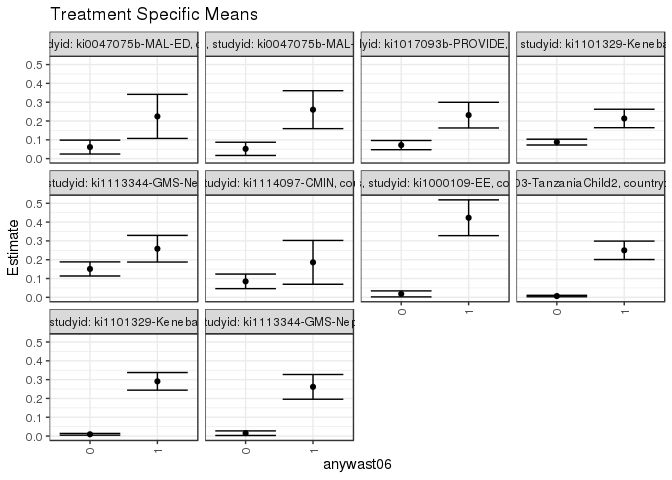

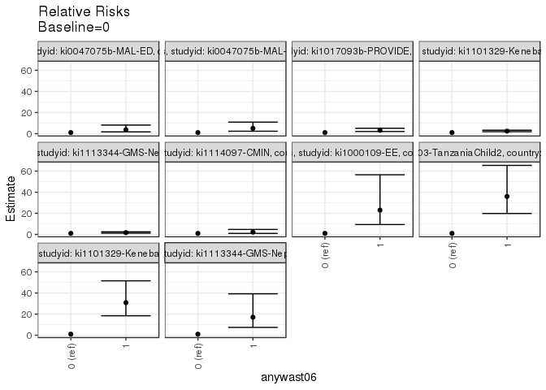

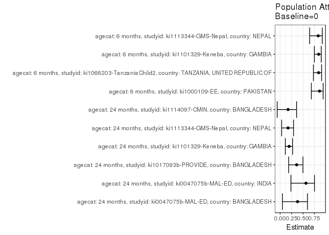

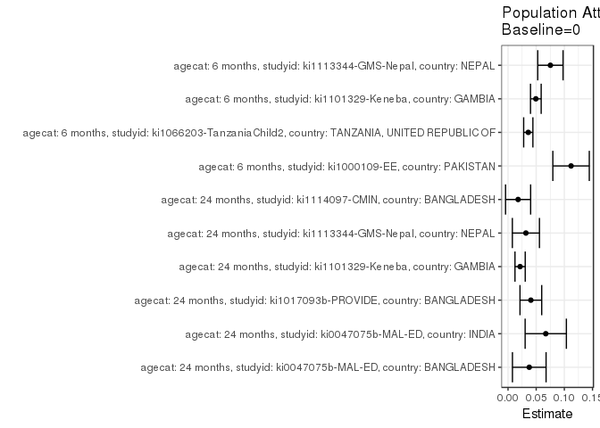

## Results Table

### Parameter: TSM

| agecat | studyid | country | intervention_level | baseline_level | estimate | ci_lower | ci_upper |
| --- | --- | --- | --- | --- | --- | --- | --- |
| 6 months | ki1000109-EE | PAKISTAN | 0 | NA | 0.0183824 | 0.0023973 | 0.0343674 |
| 6 months | ki1000109-EE | PAKISTAN | 1 | NA | 0.4230769 | 0.3279993 | 0.5181546 |
| 6 months | ki1066203-TanzaniaChild2 | TANZANIA, UNITED REPUBLIC OF | 0 | NA | 0.0069444 | 0.0030280 | 0.0108609 |
| 6 months | ki1066203-TanzaniaChild2 | TANZANIA, UNITED REPUBLIC OF | 1 | NA | 0.2500000 | 0.2009888 | 0.2990112 |
| 6 months | ki1101329-Keneba | GAMBIA | 0 | NA | 0.0094340 | 0.0048321 | 0.0140358 |
| 6 months | ki1101329-Keneba | GAMBIA | 1 | NA | 0.2908587 | 0.2439982 | 0.3377193 |
| 6 months | ki1113344-GMS-Nepal | NEPAL | 0 | NA | 0.0153453 | 0.0031505 | 0.0275401 |
| 6 months | ki1113344-GMS-Nepal | NEPAL | 1 | NA | 0.2616279 | 0.1958849 | 0.3273709 |
| 24 months | ki0047075b-MAL-ED | BANGLADESH | 0 | NA | 0.0613497 | 0.0244231 | 0.0982763 |
| 24 months | ki0047075b-MAL-ED | BANGLADESH | 1 | NA | 0.2244898 | 0.1073866 | 0.3415930 |
| 24 months | ki0047075b-MAL-ED | INDIA | 0 | NA | 0.0519481 | 0.0168206 | 0.0870755 |
| 24 months | ki0047075b-MAL-ED | INDIA | 1 | NA | 0.2602740 | 0.1593960 | 0.3611519 |
| 24 months | ki1017093b-PROVIDE | BANGLADESH | 0 | NA | 0.0719258 | 0.0475129 | 0.0963386 |
| 24 months | ki1017093b-PROVIDE | BANGLADESH | 1 | NA | 0.2312925 | 0.1630702 | 0.2995149 |
| 24 months | ki1101329-Keneba | GAMBIA | 0 | NA | 0.0878274 | 0.0724245 | 0.1032303 |
| 24 months | ki1101329-Keneba | GAMBIA | 1 | NA | 0.2134831 | 0.1643169 | 0.2626494 |
| 24 months | ki1113344-GMS-Nepal | NEPAL | 0 | NA | 0.1509972 | 0.1135024 | 0.1884919 |
| 24 months | ki1113344-GMS-Nepal | NEPAL | 1 | NA | 0.2585034 | 0.1876577 | 0.3293491 |
| 24 months | ki1114097-CMIN | BANGLADESH | 0 | NA | 0.0850000 | 0.0462699 | 0.1237301 |
| 24 months | ki1114097-CMIN | BANGLADESH | 1 | NA | 0.1860465 | 0.0694945 | 0.3025986 |

### Parameter: E(Y)

| agecat | studyid | country | intervention_level | baseline_level | estimate | ci_lower | ci_upper |
| --- | --- | --- | --- | --- | --- | --- | --- |
| 6 months | ki1000109-EE | PAKISTAN | NA | NA | 0.1303191 | 0.0962457 | 0.1643926 |
| 6 months | ki1066203-TanzaniaChild2 | TANZANIA, UNITED REPUBLIC OF | NA | NA | 0.0428994 | 0.0340782 | 0.0517206 |
| 6 months | ki1101329-Keneba | GAMBIA | NA | NA | 0.0588235 | 0.0486529 | 0.0689942 |
| 6 months | ki1113344-GMS-Nepal | NEPAL | NA | NA | 0.0905861 | 0.0668565 | 0.1143158 |
| 24 months | ki0047075b-MAL-ED | BANGLADESH | NA | NA | 0.0990566 | 0.0587480 | 0.1393652 |
| 24 months | ki0047075b-MAL-ED | INDIA | NA | NA | 0.1189427 | 0.0767376 | 0.1611478 |
| 24 months | ki1017093b-PROVIDE | BANGLADESH | NA | NA | 0.1124567 | 0.0866788 | 0.1382347 |
| 24 months | ki1101329-Keneba | GAMBIA | NA | NA | 0.1092652 | 0.0938039 | 0.1247264 |
| 24 months | ki1113344-GMS-Nepal | NEPAL | NA | NA | 0.1827309 | 0.1487560 | 0.2167058 |
| 24 months | ki1114097-CMIN | BANGLADESH | NA | NA | 0.1028807 | 0.0646041 | 0.1411572 |

### Parameter: RR

| agecat | studyid | country | intervention_level | baseline_level | estimate | ci_lower | ci_upper |
| --- | --- | --- | --- | --- | --- | --- | --- |
| 6 months | ki1000109-EE | PAKISTAN | 0 | 0 | 1.000000 | 1.000000 | 1.000000 |
| 6 months | ki1000109-EE | PAKISTAN | 1 | 0 | 23.015384 | 9.374634 | 56.504380 |
| 6 months | ki1066203-TanzaniaChild2 | TANZANIA, UNITED REPUBLIC OF | 0 | 0 | 1.000000 | 1.000000 | 1.000000 |
| 6 months | ki1066203-TanzaniaChild2 | TANZANIA, UNITED REPUBLIC OF | 1 | 0 | 35.999999 | 19.815254 | 65.404155 |
| 6 months | ki1101329-Keneba | GAMBIA | 0 | 0 | 1.000000 | 1.000000 | 1.000000 |
| 6 months | ki1101329-Keneba | GAMBIA | 1 | 0 | 30.831025 | 18.445323 | 51.533502 |
| 6 months | ki1113344-GMS-Nepal | NEPAL | 0 | 0 | 1.000000 | 1.000000 | 1.000000 |
| 6 months | ki1113344-GMS-Nepal | NEPAL | 1 | 0 | 17.049419 | 7.408582 | 39.235940 |
| 24 months | ki0047075b-MAL-ED | BANGLADESH | 0 | 0 | 1.000000 | 1.000000 | 1.000000 |
| 24 months | ki0047075b-MAL-ED | BANGLADESH | 1 | 0 | 3.659184 | 1.649957 | 8.115135 |
| 24 months | ki0047075b-MAL-ED | INDIA | 0 | 0 | 1.000000 | 1.000000 | 1.000000 |
| 24 months | ki0047075b-MAL-ED | INDIA | 1 | 0 | 5.010274 | 2.298105 | 10.923280 |
| 24 months | ki1017093b-PROVIDE | BANGLADESH | 0 | 0 | 1.000000 | 1.000000 | 1.000000 |
| 24 months | ki1017093b-PROVIDE | BANGLADESH | 1 | 0 | 3.215712 | 2.051097 | 5.041596 |
| 24 months | ki1101329-Keneba | GAMBIA | 0 | 0 | 1.000000 | 1.000000 | 1.000000 |
| 24 months | ki1101329-Keneba | GAMBIA | 1 | 0 | 2.430712 | 1.819762 | 3.246775 |
| 24 months | ki1113344-GMS-Nepal | NEPAL | 0 | 0 | 1.000000 | 1.000000 | 1.000000 |
| 24 months | ki1113344-GMS-Nepal | NEPAL | 1 | 0 | 1.711975 | 1.182729 | 2.478048 |
| 24 months | ki1114097-CMIN | BANGLADESH | 0 | 0 | 1.000000 | 1.000000 | 1.000000 |
| 24 months | ki1114097-CMIN | BANGLADESH | 1 | 0 | 2.188782 | 1.008737 | 4.749273 |

### Parameter: PAR

| agecat | studyid | country | intervention_level | baseline_level | estimate | ci_lower | ci_upper |
| --- | --- | --- | --- | --- | --- | --- | --- |
| 6 months | ki1000109-EE | PAKISTAN | 0 | NA | 0.1119368 | 0.0795820 | 0.1442916 |
| 6 months | ki1066203-TanzaniaChild2 | TANZANIA, UNITED REPUBLIC OF | 0 | NA | 0.0359550 | 0.0277688 | 0.0441411 |
| 6 months | ki1101329-Keneba | GAMBIA | 0 | NA | 0.0493896 | 0.0399187 | 0.0588605 |
| 6 months | ki1113344-GMS-Nepal | NEPAL | 0 | NA | 0.0752409 | 0.0527631 | 0.0977186 |
| 24 months | ki0047075b-MAL-ED | BANGLADESH | 0 | NA | 0.0377069 | 0.0078483 | 0.0675656 |
| 24 months | ki0047075b-MAL-ED | INDIA | 0 | NA | 0.0669947 | 0.0303755 | 0.1036139 |
| 24 months | ki1017093b-PROVIDE | BANGLADESH | 0 | NA | 0.0405310 | 0.0212525 | 0.0598095 |
| 24 months | ki1101329-Keneba | GAMBIA | 0 | NA | 0.0214377 | 0.0123409 | 0.0305346 |
| 24 months | ki1113344-GMS-Nepal | NEPAL | 0 | NA | 0.0317338 | 0.0076837 | 0.0557838 |
| 24 months | ki1114097-CMIN | BANGLADESH | 0 | NA | 0.0178807 | -0.0043891 | 0.0401504 |

### Parameter: PAF

| agecat | studyid | country | intervention_level | baseline_level | estimate | ci_lower | ci_upper |
| --- | --- | --- | --- | --- | --- | --- | --- |
| 6 months | ki1000109-EE | PAKISTAN | 0 | NA | 0.8589436 | 0.6801573 | 0.9377916 |
| 6 months | ki1066203-TanzaniaChild2 | TANZANIA, UNITED REPUBLIC OF | 0 | NA | 0.8381226 | 0.7271430 | 0.9039633 |
| 6 months | ki1101329-Keneba | GAMBIA | 0 | NA | 0.8396226 | 0.7478059 | 0.8980115 |
| 6 months | ki1113344-GMS-Nepal | NEPAL | 0 | NA | 0.8306003 | 0.6439986 | 0.9193928 |
| 24 months | ki0047075b-MAL-ED | BANGLADESH | 0 | NA | 0.3806602 | 0.0502002 | 0.5961446 |
| 24 months | ki0047075b-MAL-ED | INDIA | 0 | NA | 0.5632516 | 0.2363554 | 0.7502121 |
| 24 months | ki1017093b-PROVIDE | BANGLADESH | 0 | NA | 0.3604141 | 0.1864847 | 0.4971574 |
| 24 months | ki1101329-Keneba | GAMBIA | 0 | NA | 0.1961993 | 0.1126876 | 0.2718510 |
| 24 months | ki1113344-GMS-Nepal | NEPAL | 0 | NA | 0.1736639 | 0.0339409 | 0.2931785 |
| 24 months | ki1114097-CMIN | BANGLADESH | 0 | NA | 0.1738000 | -0.0633525 | 0.3580619 |